# 07_06_20_Phylogenetic_Regression

Lin_Zhang

7/6/2020

```r
library(rethinking)
library(ape)
library(ade4)
```

```r
data("carni70")
```

# plot the tree

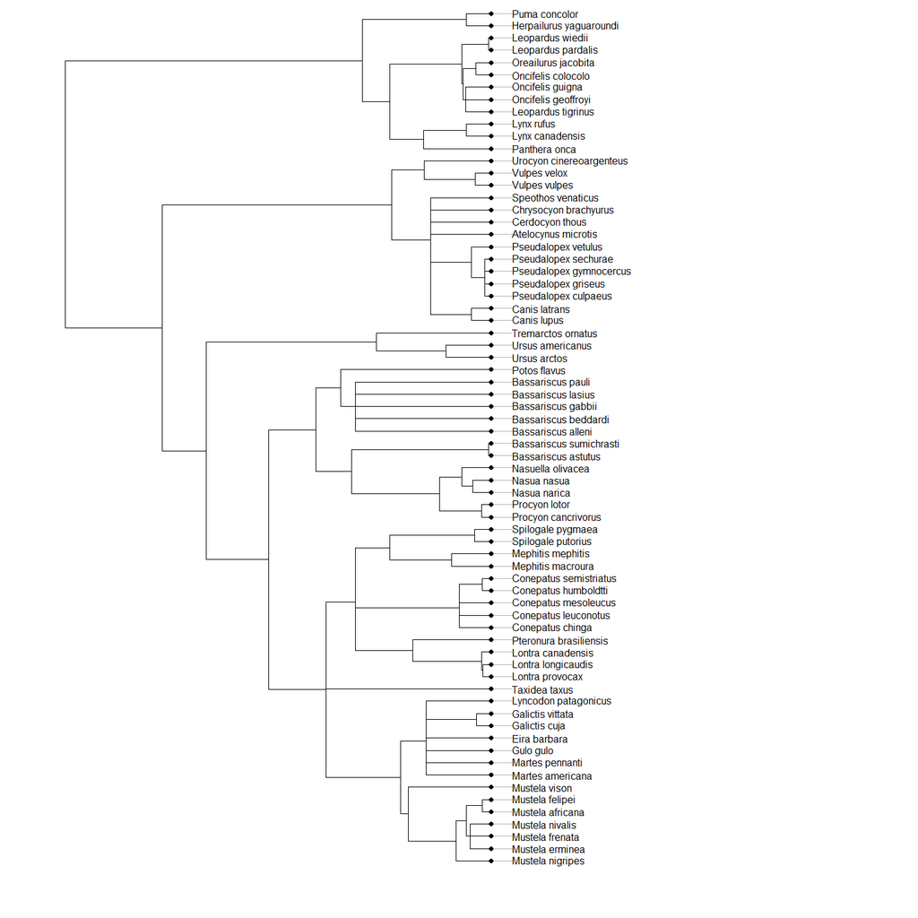

```r
  carni70.phy <- newick2phylog(carni70$tre)
  plot(carni70.phy, font=1, no.margin=TRUE,label.offset=1 , cex=0.5 )
```

# Model without Phylogenetic Regression You want to test the hypothesis that the range size of carnivores is influenced by their body size (larger carnivores roam further). You want to be sure that if you do see a relationship that is is not just due to shared evolutionary history. That is you want to do a phylogenetic regression.

```r
library(data.table)
d <- carni70$tab
setDT(d,keep.rownames = TRUE)
dstan <- d[complete.cases(d$rn,d$size,d$range),]
spp_obs <- dstan$rn
```

3. Should either range or size be transformed? I guess so

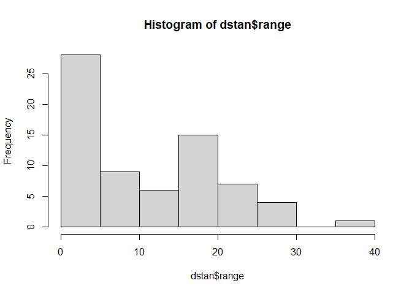

```r
hist(dstan$range)
```

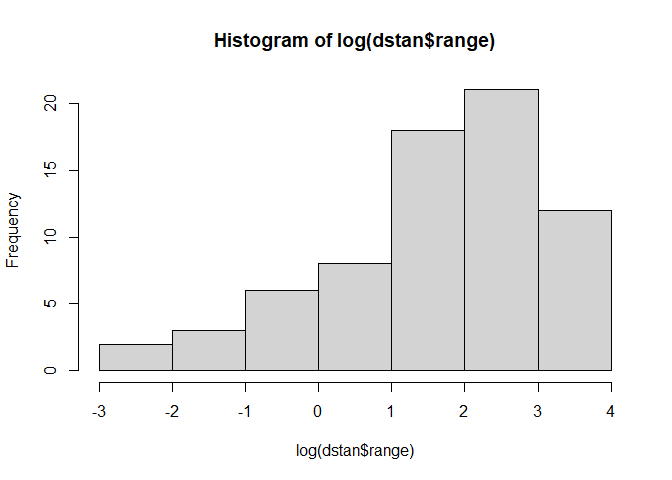

```r
hist(log(dstan$range))
```

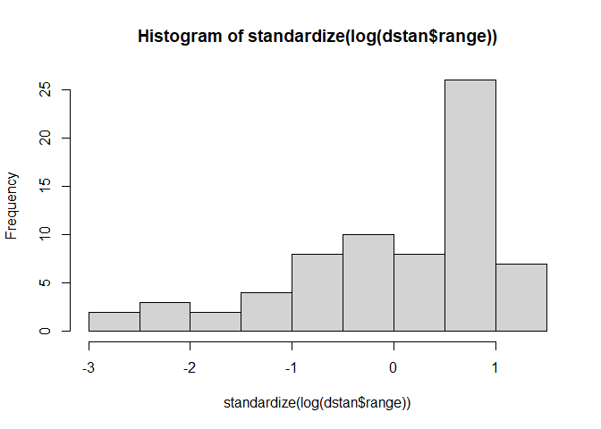

```r
hist(standardize(log(dstan$range))) #?
```

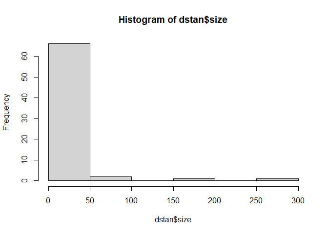

```r
hist(dstan$size)
```

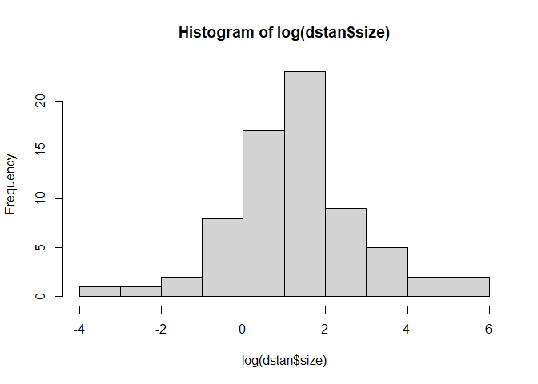

```r
hist(log(dstan$size))
```

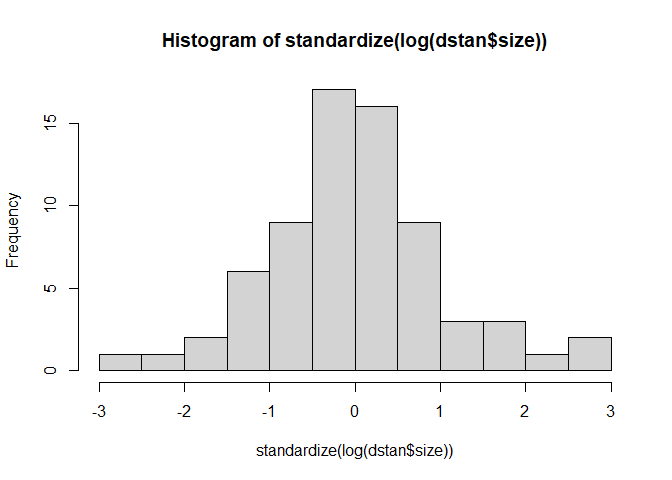

```r
hist(standardize(log(dstan$size)))
```

```r
dat_list <- list(
  N_spp = nrow(dstan),
  R = standardize(log(dstan$range)),
  S = standardize(log(dstan$size)),
  Imat = diag(nrow(dstan))
)

# without phylogenetic regression
m1 <- ulam(
  alist(
    R ~ multi_normal(mu, SIGMA),
    mu <- a + bS*S,
    matrix[N_spp,N_spp]:SIGMA <- Imat * sigma_sq,
    a ~ normal(0,1),
    bS ~ normal(0,0.5),
    sigma_sq ~ exponential(1)
      ),data = dat_list, chains = 4, cores = 4)
```

```r
precis(m1)
```

```
##                  mean        sd        5.5%     94.5%    n_eff     Rhat4
## a        -0.001696469 0.1108315 -0.17874290 0.1759601 2011.413 0.9992265
## bS        0.279527711 0.1142419  0.09161704 0.4521249 1768.483 0.9985527
## sigma_sq  0.950745274 0.1701994  0.71042916 1.2400143 1912.504 0.9994747
```

looks like a positive association between size and range. But these data are swirling with confounds.

#Phylogenetic Regression 4) Does size predict range? Evaluate this question without and with accounting for phylogenetic relationships. 2) Note that the species name given in “rownames(d)” and in “tre$tip.label” do not match. Fix that (e.g. using str_replace() ) handle it when doing Phylogenetic Regression ?

```r
#library("stringr")
#d$rn tree$tip.label look identical to me
#str_replace(d$rn,"[aeiou]",replacement = tree$tip.label)
```

## Brownian motion

```r
library(ape)
tree <- as.phylo(carni70.phy)
Rbm <- corBrownian(phy = tree)
V <- vcv(Rbm)
```

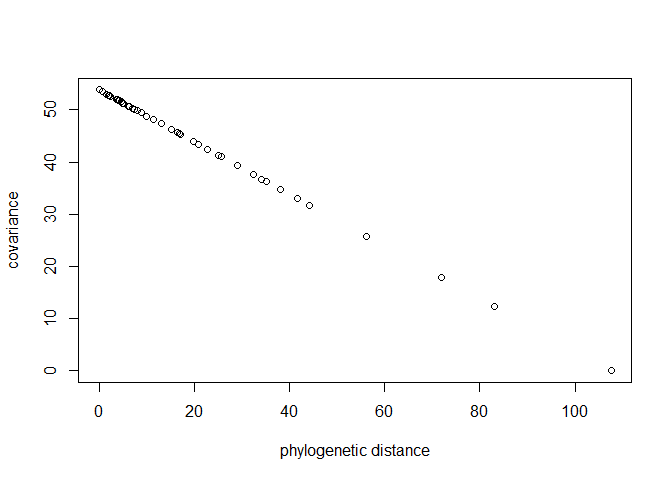

```r
Dmat <- cophenetic(tree)
plot(Dmat, V, xlab="phylogenetic distance", ylab="covariance")
```

```r
# put species in right order
dat_list$V <- V[spp_obs,spp_obs]
# convert to correlation matrix
dat_list$R <- dat_list$V/max(V)

# Brownian motion model
m2 <- ulam(
  alist(
    R ~ multi_normal(mu, SIGMA),
    mu <- a + bS*S,
    matrix[N_spp,N_spp]:SIGMA <- R * sigma_sq,
    a ~ normal(0,1),
    bS ~ normal(0,0.5),
    sigma_sq ~ exponential(1)
  ), data = dat_list, chains = 4, cores = 4
)
precis(m2)
```

```
##                  mean           sd         5.5%        94.5%     n_eff
## a         0.273865162 0.0065065452  0.263669353  0.283981715  970.0933
## bS       -0.002336607 0.0007585254 -0.003546308 -0.001114137 2216.4126
## sigma_sq  0.010362748 0.0002105595  0.010025809  0.010696166  672.2698
##              Rhat4
## a        0.9996901
## bS       0.9993503
## sigma_sq 1.0019196
```

## OU process

```r
# add scaled and reordered distance matrix
dat_list$Dmat <- Dmat[spp_obs,spp_obs]/max(Dmat)

m3 <- ulam(
  alist(
    R ~ multi_normal(mu,SIGMA),
    mu <- a + bS*S,
    matrix[N_spp,N_spp]:SIGMA <- cov_GPL1(Dmat,etasq,rhosq,0.01),
    a ~ normal(0,1),
    bS ~ normal(0,0.5),
    etasq ~ half_normal(1,0.25),
    rhosq ~ half_normal(3,0.25)
  ), data = dat_list, chains = 4, cores = 4
)

precis(m3)
```

```
##               mean          sd        5.5%        94.5%     n_eff    Rhat4
## a      0.283037387 0.042313806  0.21507557  0.348074385  674.0706 1.007641
## bS    -0.009780613 0.002590561 -0.01389753 -0.005621057 1864.9480 1.000042
## etasq  0.134815180 0.023111873  0.10216323  0.179683569  486.0497 1.007138
## rhosq  0.189132916 0.032637292  0.13716978  0.244550575  547.8335 1.006965
```